# OSMNX ile Bir Bölgede Gezilecek Yerleri İçeren En Kısa Yol Çözümü

Bu projede bir bölgeyi ziyaret etmeyi planlayan kullanıcılar için ziyaret edecekleri tüm noktaları içeren en kısa yol çözümü verilmesi hedeflenmiştir.

Bölge haritası için **OpenStreetMap** kullanılmıştır. Haritanın grafa dönüştürülmesinde **osmnx** kütüphanesi kullanılmıştır. Bir bölgede gezilebilecek turistik, doğal ve tarihi mekanların bilgisi **overpass api** ile elde edilmiştir. Bu noktaların **networkx** ile en kısa yol bilgileri elde edilmiş, hesaplanan uzaklık matrisi için **or tools** paketi ile TSP algoritması çalıştırılmıştır. Elde edilen rota **folium** kullanılarak görselleştirilmiştir.

```python
from __future__ import print_function
from ortools.constraint_solver import routing_enums_pb2
from ortools.constraint_solver import pywrapcp

import osmnx as ox
import requests
import json
import networkx as nx
from IPython.display import IFrame
import folium
import numpy as np
```

OpenStreetMap üzerinden Osmnx paketi ile İstanbul haritası çekilmiştir. Bu işlem ortalama bir bilgisayar ile yaklaşık 15dk sürmektedir. Dolayısıyla sonraki çalışmalar için graphml olarak kaydedilmiştir.

```python
#OpenStreetMap'ten bölge haritasının çekilmesi ve kaydedilmesi
#print("Harita İndiriliyor ve Graf oluşturuluyor...")
#G = ox.graph_from_place('Istanbul, Turkey', network_type='drive', which_result=2)
#ox.save_graphml(G, filename='istanbulfull.graphml')
#print("Graph Saved")
```

```python
G = ox.load_graphml('istanbulfull.graphml')
print('GrafML Dosyadan Okundu ve Graf Oluşturuldu.')
```

```
GrafML Dosyadan Okundu ve Graf Oluşturuldu.
```

**İstanbul Haritasının Graf Temsili**

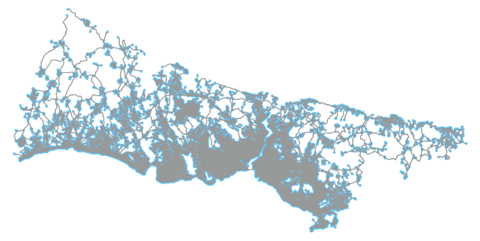

[output not shown]

```python
ox.plot_graph(G,edge_linewidth=1)
```

#### Overpass Api

Bu aşamada kullanıcıya sunacağımız POI (Point of Interest) noktalarını Overpass API'dan çekiyoruz. Şartlarımız çekilecek POI'nın turistik, tarihi veya doğal bir mekan olması. Turistik tesislerde otel vb. yerleri elemek için istediğimiz anahtar ifadeleri de uzunca belirttik.  
**POI listesi çekme işi de uzayabildiğinden çekilmiş olan listeyi bir defalığına json olarak dosyaya kaydettik. Sonraki çalışmalarda dosyadan yükledik**

```python
overpass_url = "http://overpass-api.de/api/interpreter"
overpass_query = """
[out:json];
area["name"="İstanbul"]->.a;
(
  node["tourism"~"viewpoint|zoo|theme_park|museum|picnic_site|information|gallery|camp_site|caravan_site|aquarium"]["name"](area.a);
  node["historic"~"."]["name"](area.a);
  node["natural"~"."]["name"](area.a);
);

out center;
"""

#response = requests.get(overpass_url,params={'data': overpass_query})
#data = response.json()

#with open('places.json', 'w') as outfile:
    #json.dump(data, outfile)
    #print("POI Listesi Dosyaya Kaydedildi")

with open('places.json', 'r') as f:
    data = json.load(f)
    print("POI Listesi Dosyadan Okundu")
```

[output not shown]

Bu aşamada kullanıcıya seçenekler sıra numaraları ile birlikte listeleniyor ve kullanıcının gezmek istediği yerleri seçmesi bekleniyor.

```python
# Kullanıcıya gezebileceği turistik, tarihi ve doğal yerler listelenir.
places = []
counter = 0
for element in data['elements']:
    places.append(element);
    print(str(counter) + "-" + element["tags"]["name"])
    counter+=1

print("Lütfen seçimlerinizi virgülle ayırarak yazınız");
selections = input();
selected_indexes = [int(d) for d in selections.split(',')]

user_places = []
for place_index in selected_indexes:
    user_places.append(places[place_index])
    #print(places[place_index]);

m = folium.Map(location=[40.378724, 28.7251163])
```

```
0-Yom Burnu
1-Rumeli Burnu
2-Barbaros Hayrettin Türbesi
3-Örme Dikilitaş
4-Yılanlı Sütun
5-Theodosius Dikilitaşı
6-Sabancı Üniversitesi Sakıp Sabancı Müzesi
7-Pera Müzesi
8-Sultan II. Mahmud Türbesi
9-İspirtohane
10-Siyavuşpaşa Kasrı
11-Belgrad Kapı
12-Havacılık Müzesi
13-Askeri Müze
14-Miniatürk Açıkhava Müzesi
15-BJK 100 Yıl Kartal Heykeli
16-Boğaz Manzarası
17-Bulgur Palas
18-Hatice Turhan Sultan Türbesi
19-Galata Mevlevihanesi Müzesi
20-Magnaura Sarayı
21-Petek
22-Büyük Saray Mozaikleri Müzesi
23-Osmanlı Bankası Müzesi
24-Istanbul Photography Museum
25-Mandıra Tepesi
26-ancient Substructures Hippodrom
27-Milyon Taşı
28-Gürgen Tepe
29-Gürgencik Tepesi
30-Sadberk Hanım Müzesi
31-Garipçe Kalesi
32-Pompeus Sütunu / Roke Kayalıkları
33-Rumeli Kavağı Tabyaları
34-Istanbul Sapphire
35-Haramidere Köprüsü
36-Best Point for Sea&Lake Sunset View
37-Ancient Roman Ruins
38-Büyükçekmece Kervansaray (Kurşunlu Han)
39-Büyükçekmece Kanuni Sultan Süleyman Köprüsü
```

[output cut: 306 more lines]

```
346-Tarihi Sütun
347-Harmony
348-15 Temmuz Şehitleri Zafer Anıtı
349-Atatürk Heykeli
350-Fatih Sultan Mehmet Anıtı
351-x-ist
352-İstanbul’un Orta Noktası
353-Pera Muzesi
354-SALT Beyoğlu
355-BiRL iK
356-Altıntepe
357-Kamondo Merdivenleri
358-Atatürk Anıtı
Lütfen seçimlerinizi virgülle ayırarak yazınız
353,287,300
```

Bu noktada kullanıcının seçtiği mekanların koordinat bilgisi yardımı ile graf temsilindeki en yakın düğümler tespit ediliyor. Bu noktadan sonra graf düğümleri ile çalışma devam edecek.

```python
nearest_nodes = []
for place in user_places:
    point = (place["lat"],place["lon"])
    print(place["tags"]["name"])
    nearest = ox.utils.get_nearest_node(G, point, method='haversine', return_dist=False)
    nearest_node = G.nodes[nearest]
    nearest_node["name"] = place["tags"]["name"]
    nearest_nodes.append(nearest_node)
```

```
Pera Muzesi
Tarihi Hamam
Atatürk Büstü
```

Tespit edilen düğümlerin, networkX kütüphanesi yardımı ile kendi aralarında shortest path uzunluğunu tespit ediyoruz ve bu değerlerle uzaklık matrisini oluşturuyoruz.

```python
# Tespit edilen düğümler arasında en kısa mesafeler bulunarak distance matrix elde edilir.
distance_matrix = []
for source_node in nearest_nodes:
    distance_row = []
    for target_node in nearest_nodes:
        distance = 0;
        if source_node['osmid'] != target_node['osmid']:
            distance = nx.shortest_path_length(G, source_node['osmid'],target_node['osmid'],weight='length', method='dijkstra')
        distance_row.append(distance)
    distance_matrix.append(distance_row)
print(distance_matrix)
```

```
[[0, 71534.64199999992, 37533.759999999995], [71935.356, 0, 88915.26599999997], [37803.50800000001, 90156.98599999996, 0]]
```

```python
# ORTools sonucunu yazdırmak için kullanılır.
def print_solution(manager, routing, assignment):
    """Prints assignment on console."""
    print('Mesafe: {} metre'.format(assignment.ObjectiveValue()))
    index = routing.Start(0)
    plan_output = 'izlenmesi gereken rota:\n'
    route_distance = 0
    while not routing.IsEnd(index):
        plan_output += ' {} ->'.format(manager.IndexToNode(index))
        previous_index = index
        index = assignment.Value(routing.NextVar(index))
        route_distance += routing.GetArcCostForVehicle(previous_index, index, 0)
    plan_output += ' {}\n'.format(manager.IndexToNode(index))
    print(plan_output)

# ORTools işleminden çözümü elde etmekte kullanılır.
def get_solution_route(manager, routing, assignment):
    solution = []
    index = routing.Start(0)
    while not routing.IsEnd(index):
        solution.append(manager.IndexToNode(index))
        index = assignment.Value(routing.NextVar(index))
    return solution

# Rotalar için farklı renkler
def get_route_color(index):
    colors = ['#BF360C','#D84315','#E64A19','#F4511E','#FF5722','#FF7043','#FF8A65','#FFAB91']
    return colors[index%len(colors)]

# Rotadaki duraklar için farklı renkler
def get_icon_color(index):
    colors = ['darkred','red','lightred','pink','cadetblue','darkblue','blue','lightblue']
    return colors[index%len(colors)]
```

### OR Tools

Bu noktada uzaklık matrisini OR Tools paketine veriyoruz. OR Tools TSP çalıştırarak verdiğimiz uzaklık matrisine göre en az maliyetli gezinme sırasını belirliyor.

```python
# Verinin ORTools için hazırlanması
data = {}
data['distance_matrix'] = distance_matrix
data['num_vehicles'] = 1
data['depot'] = 1

# Create the routing index manager.
manager = pywrapcp.RoutingIndexManager(len(data['distance_matrix']),
                                           data['num_vehicles'], data['depot'])

# Create Routing Model.
routing = pywrapcp.RoutingModel(manager)


def distance_callback(from_index, to_index):
    """Returns the distance between the two nodes."""
    # Convert from routing variable Index to distance matrix NodeIndex.
    from_node = manager.IndexToNode(from_index)
    to_node = manager.IndexToNode(to_index)
    return data['distance_matrix'][from_node][to_node]

transit_callback_index = routing.RegisterTransitCallback(distance_callback)

# Define cost of each arc.
routing.SetArcCostEvaluatorOfAllVehicles(transit_callback_index)

# Setting first solution heuristic.
search_parameters = pywrapcp.DefaultRoutingSearchParameters()
search_parameters.first_solution_strategy = (
    routing_enums_pb2.FirstSolutionStrategy.PATH_CHEAPEST_ARC)

# Solve the problem.
assignment = routing.SolveWithParameters(search_parameters)


if assignment:
    print_solution(manager, routing, assignment)
    solution_route = get_solution_route(manager, routing, assignment);
    print(solution_route)

    counter = 0
    for index in solution_route:
        popup_title = '<h3><strong>'+str(counter)+'.</strong> '+nearest_nodes[index]["name"]+'</h3>'
        tooltip = popup_title

        folium.Marker([nearest_nodes[index]["y"], nearest_nodes[index]["x"]], popup=popup_title,tooltip=tooltip,icon=folium.Icon(color=get_icon_color(index))).add_to(m)
        counter += 1

    counter = 0
    while counter < len(solution_route)-1:
        source_index = solution_route[counter];
        target_index = solution_route[counter+1];
        route = nx.shortest_path(G, nearest_nodes[source_index]['osmid'],nearest_nodes[target_index]['osmid'])
        m = ox.plot_route_folium(G, route, route_map=m, popup_attribute='length',fit_bounds=True,route_color=get_route_color(counter))
        counter+=1
    m.save('result.html')
    print("Harita Oluşturuldu. result.html olarak kaydedildi.")
```

```
Mesafe: 198252 metre
izlenmesi gereken rota:
 1 -> 2 -> 0 -> 1

[1, 2, 0]
Harita Oluşturuldu. result.html olarak kaydedildi.
```

```python
import folium
from IPython.display import display
LDN_COORDINATES = (40.378724, 28.7251163)
display(m)
```

[interactive chart not shown]

## Kaynaklar

-osmnx  
-[networkx](https://networkx.github.io)  
-[openstreet map wiki](https://wiki.openstreetmap.org/wiki/Main_Page)  
-[overpass api](https://wiki.openstreetmap.org/wiki/Overpass_API)  
-[overpass turbo](https://overpass-turbo.eu)  
-[folium](https://python-visualization.github.io/folium/)

#### Ersin Yıldız , ersinyildiz90[at]gmail.com